# BarCluster Tutorial

Lee Richman

01/11/2022

# Walkthrough

Welcome to BarCluster. This RMarkDown file is a tutorial using sample data to generate hybrid clusters from lineage barcoded single cell sequencing data. We will:

1. Read in our data (count matrix and barcode assignments).
2. Run PCA on our count matrix.
3. Create our hybrid clusters across a range of values.
4. Determine alpha values for analysis based on cluster number at fixed resolution.
5. Generate Sankey plots to show cluster rearrangement.
6. Identify cluster markers with ROC analysis.
7. Plot a Sankey for marker positivity.
8. Perform UMAP and warp it!

## Part 1: Setup

Load required packages, get our tutorial data files:

```r
library(data.table)
library(magrittr)
library(Seurat)
library(BarCluster)
library(ggplot2)

# get the location of the sample data
dir <- system.file(package = "BarCluster") %>% file.path(., "extdata")

cm <- file.path(dir, "YG1_sample_genes.txt")

bt <- file.path(dir, "YG1_sample_barcodes.txt")
```

Now lets read in and see what our files look like.

```r
# read in barcodes
bt <- data.table::fread(bt)

# what does it look like
head(bt)
```

```
##                  rn Barcode
## 1: AAACGAAAGAGGGTCT      C9
## 2: AAAGGTAAGGTAGTAT      C9
## 3: AAAGGTACACCATTCC      C9
## 4: AAAGGTACAGTAGTGG      C9
## 5: AAAGTGAAGGCCACCT      C9
##  [ reached getOption("max.print") -- omitted 1 row ]
```

```r
# read in count matrix
cm <- data.table::fread(cm)

# what does it look like
str(cm)
```

```
## Classes 'data.table' and 'data.frame':   501 obs. of  1424 variables:
##  $ rn              : chr  "ACTA2" "MYLK" "S100B" "CRYAB" ...
##  $ AAACGAAAGAGGGTCT: num  -0.98 -1.88 -1.51 -1.82 -1.15 ...
##  $ AAAGGTAAGGTAGTAT: num  -1.548 -1.8 -0.823 -1.786 -0.259 ...
##  $ AAAGGTACACCATTCC: num  0.685 0.852 -0.943 -1.837 -1.172 ...
##  $ AAAGGTACAGTAGTGG: num  -1.25 -1.388 -1.188 -1.485 -0.884 ...
##  $ AAAGTGAAGGCCACCT: num  -0.763 -1.638 -1.424 -1.013 -1.08 ...
##  $ AACCATGGTTTGACAC: num  -1.011 -1.613 -0.955 -1.243 -0.695 ...
##  $ AACGTCAGTACAGAGC: num  -1.268 -2.015 -1.206 -1.503 -0.898 ...
##  $ AACTTCTCAAAGGATT: num  -1.52 -1.41 -1.45 -1.76 -1.1 ...
##  $ AACTTCTTCAGCATTG: num  0.956 -1.641 -0.971 -1.26 -0.708 ...
##  $ AAGAACAAGTTGGAGC: num  5.9049 0.0941 -0.6558 -1.7195 -1.0732 ...
##  $ AAGACTCCAGTCTCTC: num  1.85 -0.504 -1.458 -1.098 -0.193 ...
##  $ AATGACCTCTTAATCC: num  -1.384 -1.306 -1.32 -1.62 -0.992 ...
##  $ AATTTCCTCCTGGGAC: num  -0.7599 0.0478 -1.423 -1.0092 -1.0786 ...
```

[output cut: 87 more lines]

Everything read in correctly but the count matrix is formatted with cells as columns (a common output format). BarCluster expects cells as rows. No problem, I’ve included functions in BarCluster to reformat the data.table.

```r
# transpose the table

cm <- tdt(cm)

# what does it look like?
str(cm)
```

```
## Classes 'data.table' and 'data.frame':   1423 obs. of  502 variables:
##  $ rn         : chr  "AAACGAAAGAGGGTCT" "AAAGGTAAGGTAGTAT" "AAAGGTACACCATTCC" "AAAGGTACAGTAGTGG" ...
##  $ ACTA2      : num  -0.98 -1.548 0.685 -1.25 -0.763 ...
##  $ MYLK       : num  -1.877 -1.8 0.852 -1.388 -1.638 ...
##  $ S100B      : num  -1.511 -0.823 -0.943 -1.188 -1.424 ...
##  $ CRYAB      : num  -1.82 -1.79 -1.84 -1.48 -1.01 ...
##  $ CCL5       : num  -1.154 -0.259 -1.172 -0.884 -1.08 ...
##  $ ACTG2      : num  -1.188 -1.163 -0.437 -0.915 -0.145 ...
##  $ TAGLN      : num  -1.068 -1.044 0.605 -0.811 -0.997 ...
##  $ A2M        : num  -1.62 -1.59 -1.64 -1.29 -1.53 ...
##  $ IFIT2      : num  -0.773 -0.752 -0.788 -0.556 -0.712 ...
##  $ IFIT3      : num  -0.848 -1.378 -1.429 -1.068 -1.317 ...
##  $ PRND       : num  0.328 -0.783 -0.818 -0.588 -0.743 ...
##  $ TFPI2      : num  15.11 11.17 5.03 0.29 15.2 ...
##  $ MMP1       : num  -0.986 -0.963 3.563 -0.742 -0.918 ...
```

[output cut: 87 more lines]

Looks good. Ok, one last setup step, turn out count matrix from a data table into a matrix.

```r
# convert data table to matrix

cm <- dt2m(cm)

# what does it look like?
str(cm)
```

```
##  num [1:1423, 1:501] -0.98 -1.548 0.685 -1.25 -0.763 ...
##  - attr(*, "dimnames")=List of 2
##   ..$ : Named chr [1:1423] "AAACGAAAGAGGGTCT" "AAAGGTAAGGTAGTAT" "AAAGGTACACCATTCC" "AAAGGTACAGTAGTGG" ...
##   .. ..- attr(*, "names")= chr [1:1423] "rn1" "rn2" "rn3" "rn4" ...
##   ..$ : chr [1:501] "ACTA2" "MYLK" "S100B" "CRYAB" ...
```

## Part 2: Perform PCA.

The next step is to generate our PCA matrix. The function `irlba_wrap` is a wrapper that will do this for you. You can set the random seed and the number of output PCs if you want, see `?irlba_wrap`. For this analysis, let’s summarize our 501 genes to 25 PCs:

```r
# using 25 PCs
pca <- irlba_wrap(cm, npc = 25)

str(pca)
```

```
##  num [1:1423, 1:25] 22.8 22.3 30.7 13.3 20.1 ...
##  - attr(*, "dimnames")=List of 2
##   ..$ : Named chr [1:1423] "AAACGAAAGAGGGTCT" "AAAGGTAAGGTAGTAT" "AAAGGTACACCATTCC" "AAAGGTACAGTAGTGG" ...
##   .. ..- attr(*, "names")= chr [1:1423] "rn1" "rn2" "rn3" "rn4" ...
##   ..$ : chr [1:25] "PC_1" "PC_2" "PC_3" "PC_4" ...
```

## Part 3: Generate hybrid clusters across a range of alpha values.

The steps to perform hybrid clustering are:

1. Generate transcriptome shared nearest neighbor graph
2. Generate binary barcode graph
3. Integrate the two with the BarCluster model
4. Repeat for many values of alpha to determine max alpha with tolerable cluster numbers.

Luckily, this is all executed with a single function whose inputs are the barcode table and the PCA we just made. The `barcluster` function does all this for one or more alpha values. The `beta` parameter will affect how each step in alpha affects the output, we are using 0.1 here, but feel free to experiment. The `res` argument is passed to the `Seurat` implementation of the Louvain algorithm. It will affect the number of clusters at low alpha, but at high alpha the determining factor is the number of barcodes in the sample. I suggest you choose a value for resolution that gives you a number of manageable clusters at alpha == 0, or simply the same value as whatever Seurat analysis you have performed on the data.

```r
# lets get our range of alpha values

als <- seq(0, 1, by = 0.1)

# return the cluster assignments for range of alphas
clust <- barcluster(pca, bt, alpha = als, beta = 0.1, res = 1.5)

print(clust)
```

[output not shown]

## Part 4: Identify target alpha values

`clust` is a data table with the cluster assignment of each cell at all alpha values. First, lets identify points to conduct our analysis by making a plot of cluster number vs alpha.

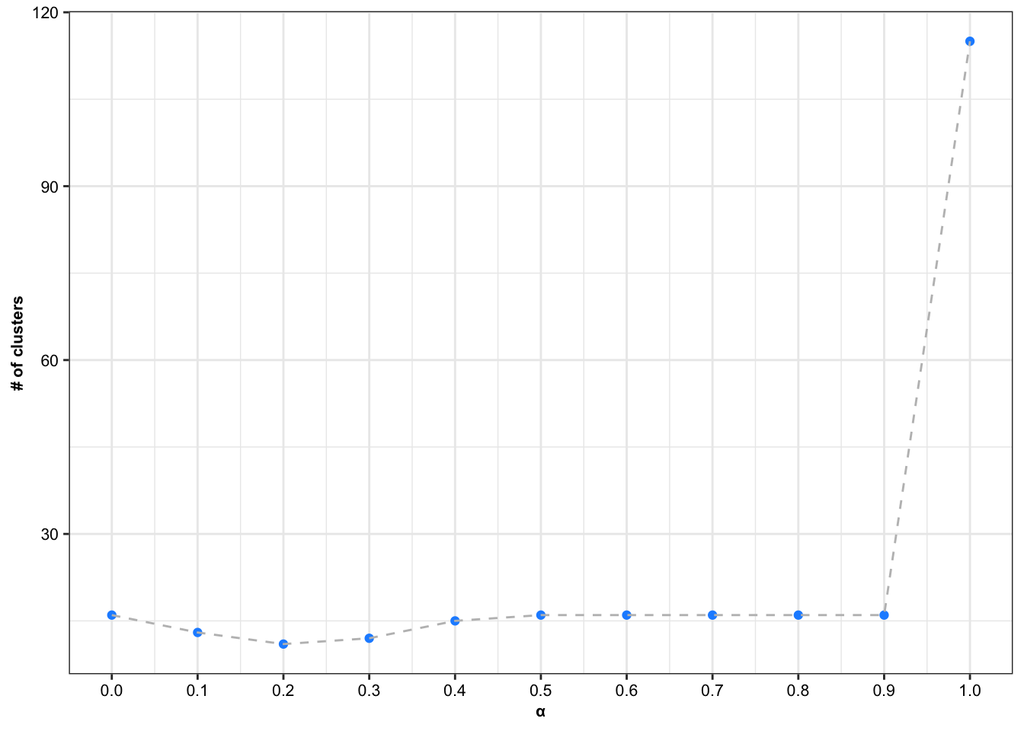

```r
nt <- clust[, Group %>% unique %>% length, by = "alpha"]

ggplot(nt, aes(x = alpha, y = V1)) +
  geom_point(color = "dodgerblue") +
  geom_line(color = "grey", linetype = "dashed") +
  theme_bw() +
  ttheme +
  xlab("\u03B1") +
  ylab("# of clusters") +
  scale_x_continuous(breaks = seq(0, 1, by = 0.1))
```

It looks like there are four interesting points on the plot for this sample data (downsampled for top barcodes and 100 singlets from the WM989 high dose BRAF inhibitor replicate 1). I’ll annotate them here:

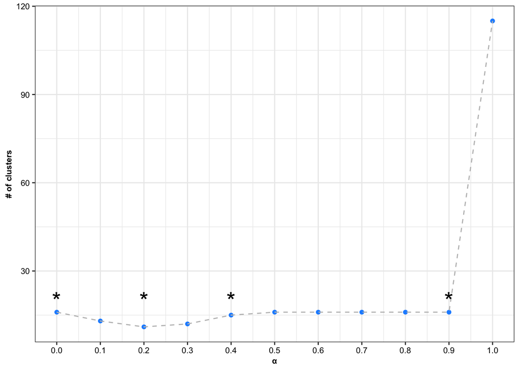

From left to right, these points are the transcriptome clusters (alpha == 0), a nadir where addition of lineage information causes clusters to join (alpha == 0.2), the inflection point (alpha == 0.4), the the maximum value before clusters break apart into barcodes (alpha == 0.9).

Let’s make a sankey plot to see the reorganization, subsetted on our alphas of interest. You could do this on the full range of alphas we ran by omitting the brackets and their contents after `clust` in the next call, but 100+ nodes on a sankey requiring individual discrete colors is not easy to grok.

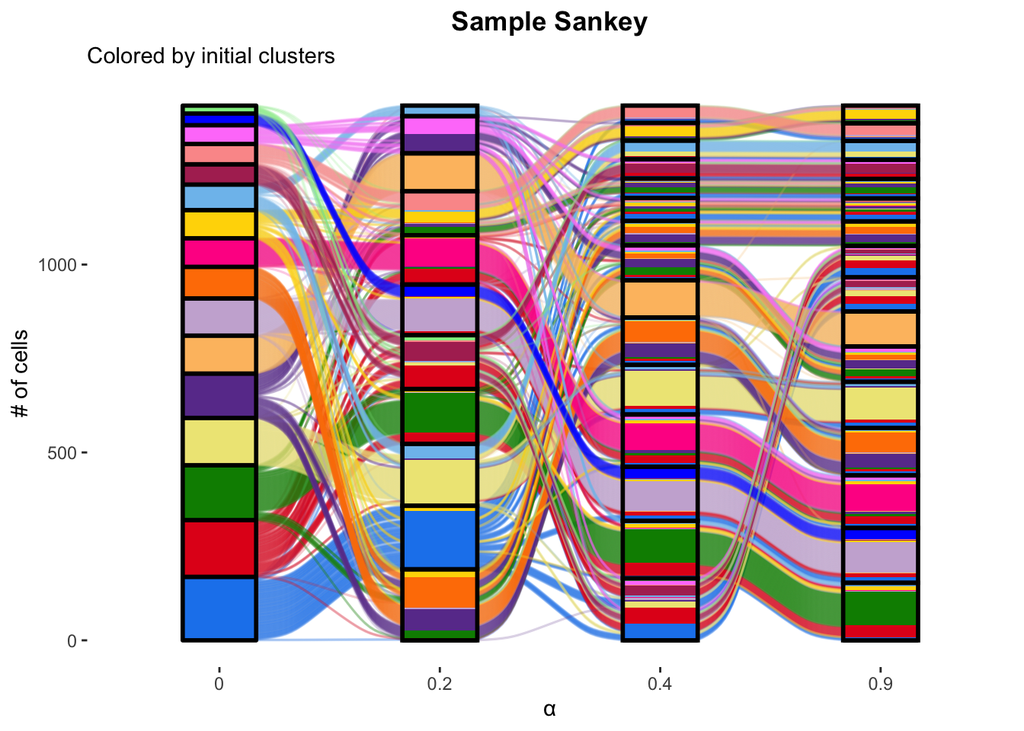

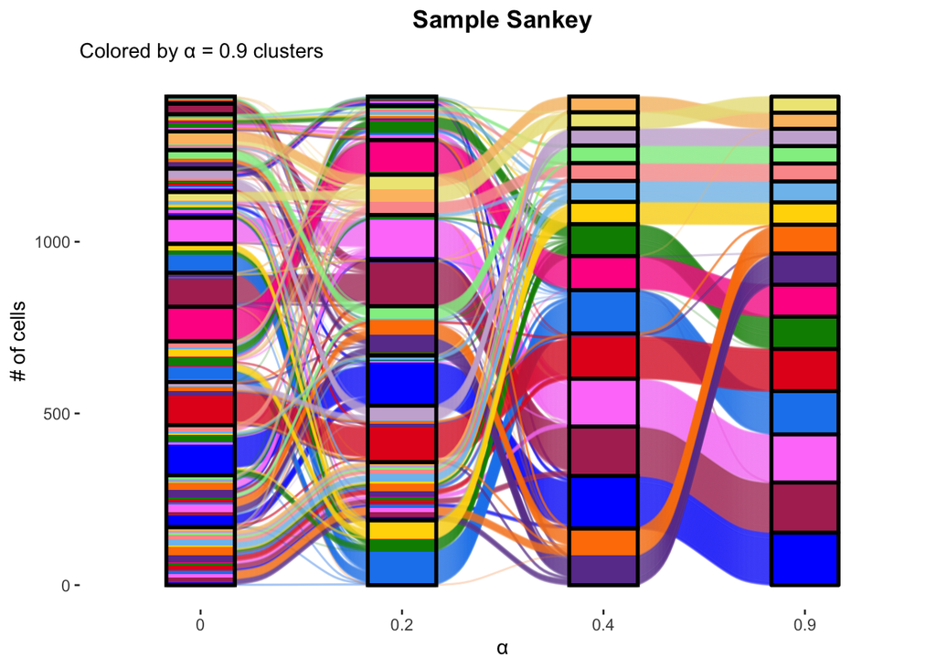

```r
notable_alphas <- c(0, 0.2, 0.4, 0.9)

p <- Plot_alluvia(clust[alpha %in% notable_alphas],
                  bt,
                  title = "Sample Sankey",
                  xlab = "\u03B1", # unicode symbol for alpha
                  ylab = "# of cells",
                  border_size = 1,
                  label_nodes = FALSE, # labels nodes but hard to viz here
                  cols = BarCluster::c25
                  )

p[[2]] <- p[[2]] + ggtitle("Sample Sankey", subtitle = "Colored by \u03B1 = 0.9 clusters")

p
```